# Market Segments

Zach Carlson

4/17/2020

## Market Segmentation

### Initial Perception

The top three most shared things in our data by mean: chatter, photo sharing, health/nutrition. The chatter makes since given that this is twitter. The other two makes sense given these are people following a health/nutrition company.

Now that I have the data scaled for clustering, I’d like to figure what value of K to use so I’m going to get an elbow plot to get a ballpark for what k to use.

### Elbow Plot

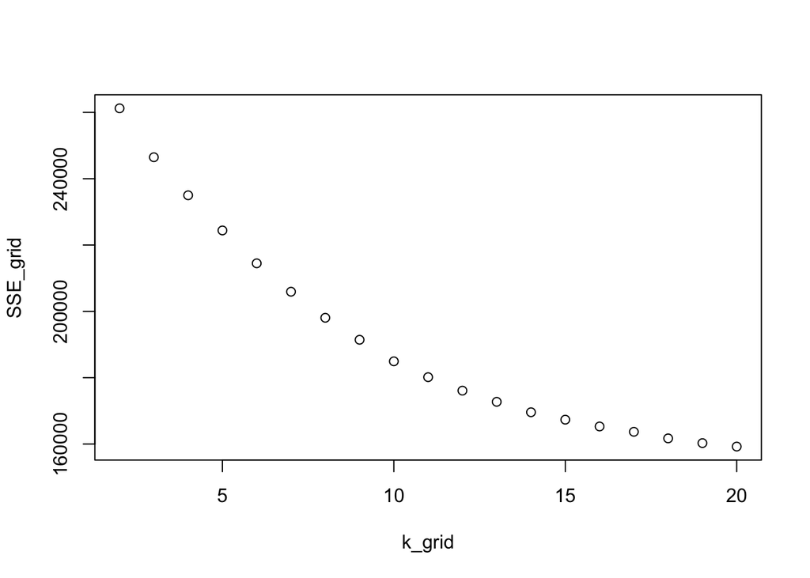

Based on this elbow plot, k=12 is probably reasonable. This is prety arbitrary. I tried to run a gap statistic to see what kind of k that indicated was correct, but the code took too long to run. I let it run for over 24 hours and it didn’t finish. So, we are going to proceed with k=12.

### Clustering

```
## [1] 176097.5
```

```
## [1] 176097.9
```

```
## [1] 107618.5
```

```
## [1] 107618.1
```

### Cluster Summaries

#### Cluster 1

Table continues below

| chatter | current_events | travel | photo_sharing | uncategorized | tv_film |
| --- | --- | --- | --- | --- | --- |
| 4.14 | 1.758 | 1.461 | 6.126 | 1.275 | 0.8448 |

Table continues below

| sports_fandom | politics | food | family | home_and_garden | music | news |
| --- | --- | --- | --- | --- | --- | --- |
| 1.115 | 1.386 | 1.038 | 0.9024 | 0.6164 | 1.251 | 1.027 |

Table continues below

| online_gaming | shopping | health_nutrition | college_uni | sports_playing |
| --- | --- | --- | --- | --- |
| 1.169 | 1.754 | 2.275 | 1.532 | 0.8248 |

Table continues below

| cooking | eco | computers | business | outdoors | crafts | automotive |
| --- | --- | --- | --- | --- | --- | --- |
| 11.85 | 0.5122 | 0.7317 | 0.5787 | 0.8071 | 0.5831 | 0.8448 |

Table continues below

| art | religion | beauty | parenting | dating | school | personal_fitness |
| --- | --- | --- | --- | --- | --- | --- |
| 0.7517 | 0.8514 | 4.288 | 0.816 | 0.6275 | 0.929 | 1.361 |

| fashion | small_business | spam | adult |
| --- | --- | --- | --- |
| 6.058 | 0.4457 | 4.337e-17 | 0.2195 |

#### Cluster 2

Table continues below

| chatter | current_events | travel | photo_sharing | uncategorized | tv_film |
| --- | --- | --- | --- | --- | --- |
| 3.075 | 1.267 | 1.068 | 1.555 | 0.6338 | 0.7079 |

Table continues below

| sports_fandom | politics | food | family | home_and_garden | music | news |
| --- | --- | --- | --- | --- | --- | --- |
| 0.9058 | 0.8825 | 0.7506 | 0.5101 | 0.3671 | 0.4466 | 0.5524 |

Table continues below

| online_gaming | shopping | health_nutrition | college_uni | sports_playing |
| --- | --- | --- | --- | --- |
| 0.5795 | 0.68 | 1.157 | 0.816 | 0.3844 |

Table continues below

| cooking | eco | computers | business | outdoors | crafts | automotive |
| --- | --- | --- | --- | --- | --- | --- |
| 0.9017 | 0.2952 | 0.3376 | 0.2531 | 0.3719 | 0.2732 | 0.4004 |

Table continues below

| art | religion | beauty | parenting | dating | school | personal_fitness |
| --- | --- | --- | --- | --- | --- | --- |
| 0.3288 | 0.5258 | 0.3433 | 0.4212 | 0.326 | 0.3734 | 0.6523 |

| fashion | small_business | spam | adult |
| --- | --- | --- | --- |
| 0.4589 | 0.1976 | -2.628e-16 | 0.1062 |

#### Cluster 3

Table continues below

| chatter | current_events | travel | photo_sharing | uncategorized | tv_film |
| --- | --- | --- | --- | --- | --- |
| 4.067 | 1.663 | 9.126 | 2.37 | 0.7185 | 0.9707 |

Table continues below

| sports_fandom | politics | food | family | home_and_garden | music | news |
| --- | --- | --- | --- | --- | --- | --- |
| 1.147 | 11.34 | 1.701 | 0.7713 | 0.563 | 0.6393 | 3.628 |

Table continues below

| online_gaming | shopping | health_nutrition | college_uni | sports_playing |
| --- | --- | --- | --- | --- |
| 0.7566 | 1.249 | 1.815 | 1.425 | 0.6804 |

Table continues below

| cooking | eco | computers | business | outdoors | crafts | automotive |
| --- | --- | --- | --- | --- | --- | --- |
| 1.364 | 0.6276 | 4.109 | 0.8123 | 0.739 | 0.6716 | 0.654 |

Table continues below

| art | religion | beauty | parenting | dating | school | personal_fitness |
| --- | --- | --- | --- | --- | --- | --- |
| 0.4721 | 1.334 | 0.4545 | 0.9501 | 1.135 | 0.6276 | 1.103 |

| fashion | small_business | spam | adult |
| --- | --- | --- | --- |
| 0.6657 | 0.5777 | 4.77e-17 | 0.08504 |

#### Cluster 4

Table continues below

| chatter | current_events | travel | photo_sharing | uncategorized | tv_film |
| --- | --- | --- | --- | --- | --- |
| 4.12 | 1.607 | 1.161 | 2.103 | 0.7242 | 1.058 |

Table continues below

| sports_fandom | politics | food | family | home_and_garden | music | news |
| --- | --- | --- | --- | --- | --- | --- |
| 3.079 | 5.53 | 1.129 | 1.125 | 0.6235 | 0.5947 | 6.866 |

Table continues below

| online_gaming | shopping | health_nutrition | college_uni | sports_playing |
| --- | --- | --- | --- | --- |
| 0.8753 | 1.055 | 1.472 | 0.9904 | 0.5492 |

Table continues below

| cooking | eco | computers | business | outdoors | crafts | automotive |
| --- | --- | --- | --- | --- | --- | --- |
| 1.211 | 0.4293 | 0.4245 | 0.3453 | 1.134 | 0.3837 | 4.403 |

Table continues below

| art | religion | beauty | parenting | dating | school | personal_fitness |
| --- | --- | --- | --- | --- | --- | --- |
| 0.47 | 0.753 | 0.4748 | 0.9856 | 0.5516 | 0.7698 | 0.9137 |

| fashion | small_business | spam | adult |
| --- | --- | --- | --- |
| 0.5803 | 0.2326 | 5.898e-17 | 0.07194 |

#### Cluster 5

Table continues below

| chatter | current_events | travel | photo_sharing | uncategorized | tv_film |
| --- | --- | --- | --- | --- | --- |
| 9.764 | 1.987 | 1.098 | 6.004 | 0.8056 | 0.8419 |

Table continues below

| sports_fandom | politics | food | family | home_and_garden | music | news |
| --- | --- | --- | --- | --- | --- | --- |
| 1.167 | 1.376 | 0.8387 | 0.8248 | 0.5566 | 0.8376 | 0.6421 |

Table continues below

| online_gaming | shopping | health_nutrition | college_uni | sports_playing |
| --- | --- | --- | --- | --- |
| 0.7489 | 4.158 | 1.619 | 1.231 | 0.5524 |

Table continues below

| cooking | eco | computers | business | outdoors | crafts | automotive |
| --- | --- | --- | --- | --- | --- | --- |
| 1.24 | 0.7415 | 0.5962 | 0.6474 | 0.4583 | 0.5214 | 0.9658 |

Table continues below

| art | religion | beauty | parenting | dating | school | personal_fitness |
| --- | --- | --- | --- | --- | --- | --- |
| 0.3729 | 0.5609 | 0.3942 | 0.5908 | 0.4391 | 0.7137 | 1.075 |

| fashion | small_business | spam | adult |
| --- | --- | --- | --- |
| 0.7201 | 0.4103 | 9.541e-18 | 0.1197 |

#### Cluster 6

Table continues below

| chatter | current_events | travel | photo_sharing | uncategorized | tv_film |
| --- | --- | --- | --- | --- | --- |
| 3.753 | 1.49 | 1.217 | 2.347 | 0.9358 | 0.8251 |

Table continues below

| sports_fandom | politics | food | family | home_and_garden | music | news |
| --- | --- | --- | --- | --- | --- | --- |
| 1.178 | 1.167 | 2.23 | 0.7486 | 0.612 | 0.6639 | 1.057 |

Table continues below

| online_gaming | shopping | health_nutrition | college_uni | sports_playing |
| --- | --- | --- | --- | --- |
| 0.8948 | 1.261 | 12.72 | 0.9235 | 0.597 |

Table continues below

| cooking | eco | computers | business | outdoors | crafts | automotive |
| --- | --- | --- | --- | --- | --- | --- |
| 3.428 | 0.9481 | 0.5492 | 0.444 | 2.899 | 0.5806 | 0.5683 |

Table continues below

| art | religion | beauty | parenting | dating | school | personal_fitness |
| --- | --- | --- | --- | --- | --- | --- |
| 0.5929 | 0.791 | 0.4194 | 0.776 | 0.7923 | 0.5096 | 6.702 |

| fashion | small_business | spam | adult |
| --- | --- | --- | --- |
| 0.7486 | 0.2377 | -3.556e-17 | 0.1694 |

#### Cluster 7

Table continues below

| chatter | current_events | travel | photo_sharing | uncategorized | tv_film |
| --- | --- | --- | --- | --- | --- |
| 4.032 | 1.416 | 1.504 | 2.657 | 0.7625 | 1.252 |

Table continues below

| sports_fandom | politics | food | family | home_and_garden | music | news |
| --- | --- | --- | --- | --- | --- | --- |
| 1.302 | 1.261 | 1.223 | 1.1 | 0.563 | 0.6246 | 0.8152 |

Table continues below

| online_gaming | shopping | health_nutrition | college_uni | sports_playing |
| --- | --- | --- | --- | --- |
| 10.98 | 1.141 | 1.771 | 11.23 | 2.768 |

Table continues below

| cooking | eco | computers | business | outdoors | crafts | automotive |
| --- | --- | --- | --- | --- | --- | --- |
| 1.575 | 0.4633 | 0.5513 | 0.3578 | 0.6246 | 0.5367 | 0.912 |

Table continues below

| art | religion | beauty | parenting | dating | school | personal_fitness |
| --- | --- | --- | --- | --- | --- | --- |
| 1.182 | 0.7361 | 0.3959 | 0.7243 | 0.6569 | 0.4897 | 1.041 |

| fashion | small_business | spam | adult |
| --- | --- | --- | --- |
| 0.8475 | 0.4018 | 4.77e-17 | 0.173 |

#### Cluster 8

Table continues below

| chatter | current_events | travel | photo_sharing | uncategorized | tv_film |
| --- | --- | --- | --- | --- | --- |
| 3.842 | 1.649 | 1.348 | 2.454 | 0.6973 | 0.9158 |

Table continues below

| sports_fandom | politics | food | family | home_and_garden | music | news |
| --- | --- | --- | --- | --- | --- | --- |
| 6.19 | 1.114 | 4.769 | 2.627 | 0.6459 | 0.7129 | 0.9813 |

Table continues below

| online_gaming | shopping | health_nutrition | college_uni | sports_playing |
| --- | --- | --- | --- | --- |
| 0.9984 | 1.354 | 1.919 | 1.178 | 0.7363 |

Table continues below

| cooking | eco | computers | business | outdoors | crafts | automotive |
| --- | --- | --- | --- | --- | --- | --- |
| 1.691 | 0.6427 | 0.7457 | 0.4961 | 0.6771 | 1.078 | 0.9938 |

Table continues below

| art | religion | beauty | parenting | dating | school | personal_fitness |
| --- | --- | --- | --- | --- | --- | --- |
| 0.6817 | 5.552 | 1.134 | 4.262 | 0.5133 | 2.76 | 1.225 |

| fashion | small_business | spam | adult |
| --- | --- | --- | --- |
| 1.005 | 0.3885 | -1.648e-17 | 0.2246 |

#### Cluster 9

Table continues below

| chatter | current_events | travel | photo_sharing | uncategorized | tv_film |
| --- | --- | --- | --- | --- | --- |
| 4.323 | 1.487 | 1.574 | 2.138 | 1.051 | 0.7077 |

Table continues below

| sports_fandom | politics | food | family | home_and_garden | music | news |
| --- | --- | --- | --- | --- | --- | --- |
| 1.262 | 1.133 | 1.272 | 0.9538 | 0.5487 | 0.6564 | 0.8667 |

Table continues below

| online_gaming | shopping | health_nutrition | college_uni | sports_playing |
| --- | --- | --- | --- | --- |
| 1.195 | 1.041 | 1.728 | 1.179 | 0.4974 |

Table continues below

| cooking | eco | computers | business | outdoors | crafts | automotive |
| --- | --- | --- | --- | --- | --- | --- |
| 1.395 | 0.6308 | 0.7333 | 0.3385 | 1.087 | 0.5333 | 0.9692 |

Table continues below

| art | religion | beauty | parenting | dating | school | personal_fitness |
| --- | --- | --- | --- | --- | --- | --- |
| 0.5692 | 0.7744 | 0.6205 | 1.031 | 0.5538 | 0.8205 | 1.282 |

| fashion | small_business | spam | adult |
| --- | --- | --- | --- |
| 0.7179 | 0.5949 | -9.541e-18 | 9.051 |

#### Cluster 10

Table continues below

| chatter | current_events | travel | photo_sharing | uncategorized | tv_film |
| --- | --- | --- | --- | --- | --- |
| 4.653 | 1.878 | 2.245 | 2.449 | 0.9184 | 0.8776 |

Table continues below

| sports_fandom | politics | food | family | home_and_garden | music | news |
| --- | --- | --- | --- | --- | --- | --- |
| 1.898 | 2.245 | 1.469 | 0.7959 | 0.6939 | 0.6939 | 1.204 |

Table continues below

| online_gaming | shopping | health_nutrition | college_uni | sports_playing |
| --- | --- | --- | --- | --- |
| 1.449 | 0.9592 | 2.796 | 1.918 | 0.5306 |

Table continues below

| cooking | eco | computers | business | outdoors | crafts | automotive |
| --- | --- | --- | --- | --- | --- | --- |
| 1.796 | 0.8571 | 1 | 0.1837 | 1.143 | 0.6939 | 1 |

Table continues below

| art | religion | beauty | parenting | dating | school | personal_fitness |
| --- | --- | --- | --- | --- | --- | --- |
| 1.265 | 1.327 | 0.5714 | 1.204 | 0.6939 | 0.8776 | 1.755 |

| fashion | small_business | spam | adult |
| --- | --- | --- | --- |
| 0.9592 | 0.5306 | 1.041 | 7.204 |

#### Cluster 11

Table continues below

| chatter | current_events | travel | photo_sharing | uncategorized | tv_film |
| --- | --- | --- | --- | --- | --- |
| 7.943 | 1.615 | 1.469 | 2.641 | 1.526 | 0.9427 |

Table continues below

| sports_fandom | politics | food | family | home_and_garden | music | news |
| --- | --- | --- | --- | --- | --- | --- |
| 1.344 | 1.328 | 1.167 | 0.7604 | 0.9479 | 0.651 | 0.9271 |

Table continues below

| online_gaming | shopping | health_nutrition | college_uni | sports_playing |
| --- | --- | --- | --- | --- |
| 1.042 | 1.229 | 2.141 | 1.427 | 0.9479 |

Table continues below

| cooking | eco | computers | business | outdoors | crafts | automotive |
| --- | --- | --- | --- | --- | --- | --- |
| 1.531 | 0.6146 | 0.6719 | 0.7292 | 0.8594 | 0.849 | 0.5729 |

Table continues below

| art | religion | beauty | parenting | dating | school | personal_fitness |
| --- | --- | --- | --- | --- | --- | --- |
| 0.6875 | 1.193 | 1.062 | 1.078 | 9.349 | 2.281 | 1.323 |

| fashion | small_business | spam | adult |
| --- | --- | --- | --- |
| 2.51 | 0.5573 | -9.541e-18 | 0.2448 |

#### Cluster 12

Table continues below

| chatter | current_events | travel | photo_sharing | uncategorized | tv_film |
| --- | --- | --- | --- | --- | --- |
| 3.94 | 1.943 | 2.089 | 2.471 | 1.437 | 5.61 |

Table continues below

| sports_fandom | politics | food | family | home_and_garden | music | news |
| --- | --- | --- | --- | --- | --- | --- |
| 1.337 | 1.536 | 1.665 | 0.7345 | 0.7618 | 1.675 | 1.221 |

Table continues below

| online_gaming | shopping | health_nutrition | college_uni | sports_playing |
| --- | --- | --- | --- | --- |
| 0.7146 | 1.417 | 1.861 | 2.516 | 0.7593 |

Table continues below

| cooking | eco | computers | business | outdoors | crafts | automotive |
| --- | --- | --- | --- | --- | --- | --- |
| 1.536 | 0.5782 | 0.4615 | 0.6501 | 0.6576 | 1.132 | 0.5211 |

Table continues below

| art | religion | beauty | parenting | dating | school | personal_fitness |
| --- | --- | --- | --- | --- | --- | --- |
| 5.067 | 1.112 | 0.7122 | 0.6228 | 0.4566 | 0.7196 | 1.077 |

| fashion | small_business | spam | adult |
| --- | --- | --- | --- |
| 0.9156 | 0.8288 | 6.158e-17 | 0.196 |

#### Cluster sizes

*451*, *3184*, *341*, *417*, *936*, *732*, *341*, *641*, *195*, *49*, *192* and *403* These are giving us the values for the center of the different clusters which will help us see patterns of tweeting in different market segments. I also called the cluster sizes so we can see how many people fell into each market segment/cluster

There are definitely some distinct groups that can be seen in these clusters.I will come back to these at the end of the report. Now, I’d like to look at what a PCA approach would look like for this.

### PCAs

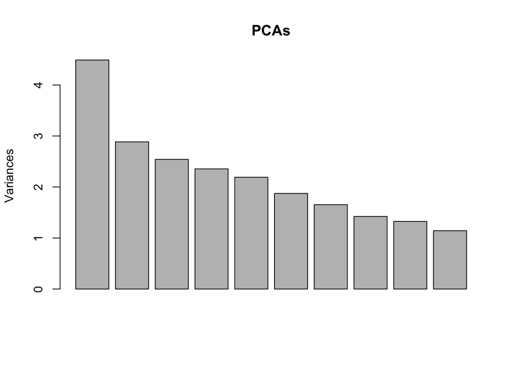

```
## Importance of components:
##                           PC1     PC2     PC3     PC4     PC5     PC6
## Standard deviation     2.1186 1.69824 1.59388 1.53457 1.48027 1.36885
## Proportion of Variance 0.1247 0.08011 0.07057 0.06541 0.06087 0.05205
## Cumulative Proportion  0.1247 0.20479 0.27536 0.34077 0.40164 0.45369
##                            PC7     PC8     PC9    PC10    PC11    PC12
## Standard deviation     1.28577 1.19277 1.15127 1.06930 1.00566 0.96785
## Proportion of Variance 0.04592 0.03952 0.03682 0.03176 0.02809 0.02602
## Cumulative Proportion  0.49961 0.53913 0.57595 0.60771 0.63580 0.66182
##                           PC13    PC14    PC15    PC16   PC17    PC18
## Standard deviation     0.96131 0.94405 0.93297 0.91698 0.9020 0.85869
## Proportion of Variance 0.02567 0.02476 0.02418 0.02336 0.0226 0.02048
## Cumulative Proportion  0.68749 0.71225 0.73643 0.75979 0.7824 0.80287
##                           PC19    PC20    PC21    PC22    PC23    PC24
## Standard deviation     0.83466 0.80544 0.75311 0.69632 0.68558 0.65317
## Proportion of Variance 0.01935 0.01802 0.01575 0.01347 0.01306 0.01185
## Cumulative Proportion  0.82222 0.84024 0.85599 0.86946 0.88252 0.89437
##                           PC25    PC26    PC27    PC28    PC29    PC30
## Standard deviation     0.64881 0.63756 0.63626 0.61513 0.60167 0.59424
## Proportion of Variance 0.01169 0.01129 0.01125 0.01051 0.01006 0.00981
## Cumulative Proportion  0.90606 0.91735 0.92860 0.93911 0.94917 0.95898
##                           PC31   PC32    PC33    PC34    PC35    PC36
## Standard deviation     0.58683 0.5498 0.48442 0.47576 0.43757 0.42165
## Proportion of Variance 0.00957 0.0084 0.00652 0.00629 0.00532 0.00494
## Cumulative Proportion  0.96854 0.9769 0.98346 0.98974 0.99506 1.00000
```

Examining the summary, we can see that to conserve 75% of the variance, you’d have to go with 16 PCAs, which makes it seem like most of the features are relatively uncorrelated and shouldn’t be compressed. I would rather go with clustering here, which won’t be as destructive to the variance.

Number of people in each cluster: cluster 1: 451 cluster 2: 3184 cluster 3: 341 cluster 4: 417 cluster 5: 936 cluster 6: 732 cluster 7: 341 cluster 8: 641 cluster 9: 195 cluster 10: 49 cluster 11: 192 cluster 12: 403

Using the K++ clustering as our main descriptive tool here, we can see some distinct groups of followers for NutrientH2O:

### Clusters 9 and 10

Clusters 9 and 10 shared more adult content than any other category of content, so NutrientH2O should be aware of this cluster. They may want to block some of these accounts from interacting with them. From a marketing perspective, NutrientH2O probably doesn’t want to be associated with adult content accounts. These are also the smallest and third smallest cluster in terms of twitter accounts, so this isn’t a very big chunk of NutrientH2O’s followers.

### Cluster 12

Cluster 12 was sharing a lot about TV/film/art and college, which could be useful information for NutrientH2O. Knowing that they have followers into the arts, they could try to do some targeted advertising related to movies, popular tv shoes, colleges, etc. This cluster is 403 people which is a sizable amount.

### Cluster 8

Cluster 8 was sharing a lot about sports fandom, parenting, food and religion. This could be another interesting market segment to try to appeal to through targetted marketing somehow since they are the fourth biggest market segment. NutrientH2O could try to advertise through the sports they are fans of, or through their children/ religious institution. You can see below that cluster 8 is dominating when it comes to sharing a lot about both religion and sports fandom.

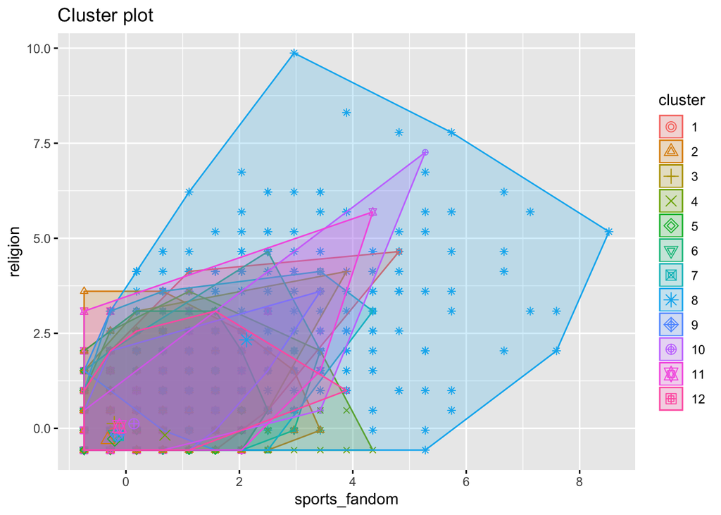

### Cluster 3 and 4

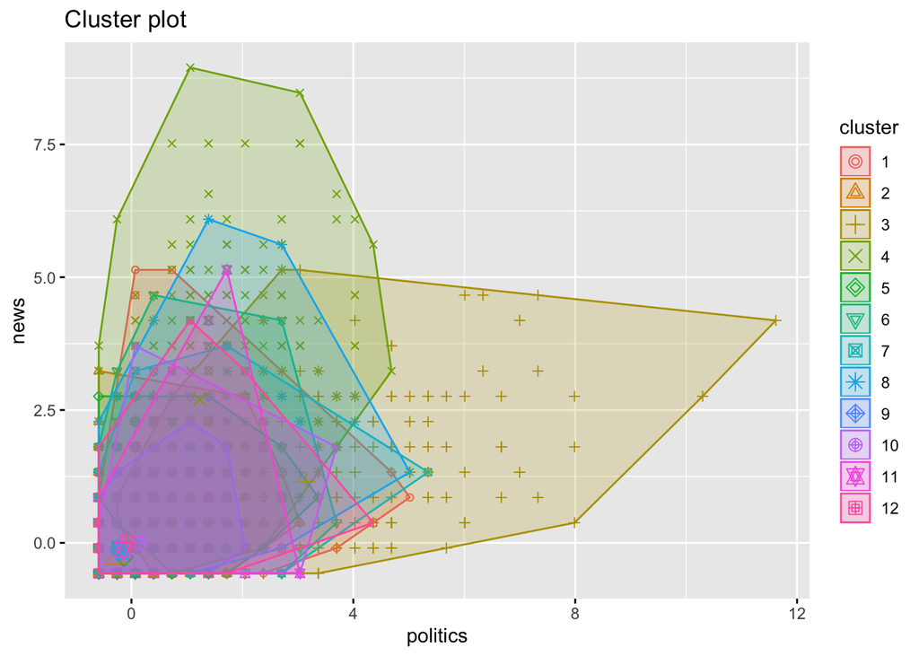

### Cluster 2

Our biggest cluster was cluster 2. Cluster 2 has 3184 members, whearas the next biggest cluster only has 936. Basiaclly, cluster 2 is massive. Cluster 2 is tricky because the cluster center is below average on every category of tweet. This suggests to me that cluster 2 may be capturing the inactive/relatively inactive group of followers that NutrientH2O has. The categories they are most active in are chatter, photo sharing, current events, health and nutrition, travel, and sports fandom, in that order. The fact that cluster 2 represent a fairly in active group on twitter can best be seen from our PCA analysis. We see all the variation vectors pointing left because the first PCA coincides with inactiveness on twitter.

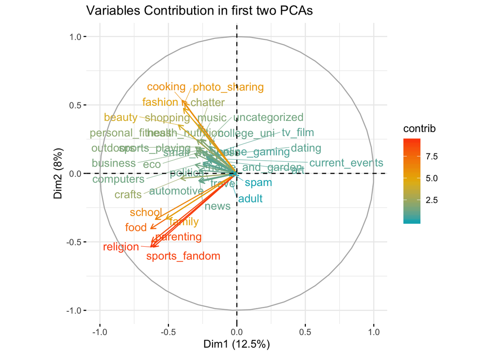

### Cluster 5

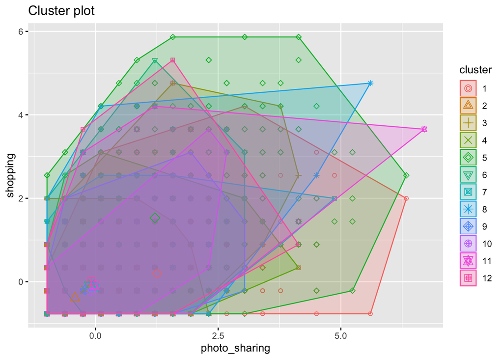

### Conclusion

These are just a few of the interesting market segments I saw in the clusters, but you could formulate advertising plans for more or less of the clusters here. It’s up to the advertising firm which of these clusters of the NutrientH2O audience they want to utilize.

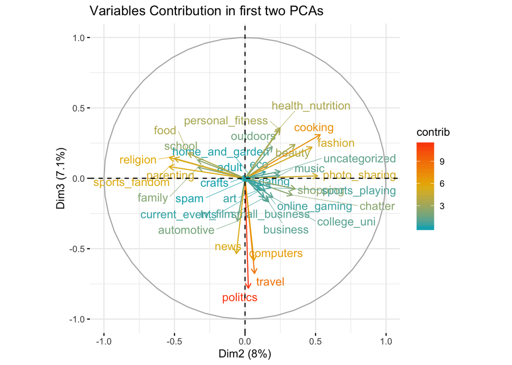

Looking at PCA 2 and PCA 3(we took out the PCA1 because this largely represent how inactive people are), you can see the related topics, and how the vectors are pointing in similar directions when they are clustered together. This provides a nice grouping of intersts for NutrientH2O to utilize in their advertising focus. In conclusion, one market segment to focus on is interested in religion/sportsfandom/parenting/food/school/family. A second market segment to focus on is intersted in news/computers/travel/politics. A third market segment to focus on is interested in photo sharing/shopping/fashion/cooking/nutrition/health/chatter/beauty.